# Multiple regression: feature selection and model diagnostics

Gleb Zakhodyakin, postlogist@gmail.com

16.09.2019

# Introduction

A multiple regression can include several explanatory variables from the dataset. The question is, which variables to include? This tutorial shows methods available to deal with the variable, or feature selection problem. We consider prediction of car’s fuel efficiency based on car’s attributes. We also consider ways to determine the most influential predictors as well as to improve the model’s fit by including non-linear terms. Finally, redisual diagnostics is performed to judge upon the model’s quality.

# Preparation

## Loading packages

```r
library(memisc) # model comparison in a table
library(leaps) # best subsets regression
library(car) # power transforms
library(glmnet) # Lasso and Ridge regression
library(tidyverse) # data manipulation
library(GGally) # scatterplot matrices in ggplot
library(ggfortify) # diagnostic plots in ggplot
library(modelr) # useful functions to work with modeling results in tidyverse
library(broom) # for tidying the modeling results
```

## Loading data

```r
cars <- read_csv2("datasets/cars.csv", skip = 25)
```

The data contains a few missing observations. Here we get rid of them.

```r
cars <- na.omit(cars)
```

# The Multicollinearity Problem

## The source of Multicollinearity

Let’s consider a scatterplot matrix for car’s features.

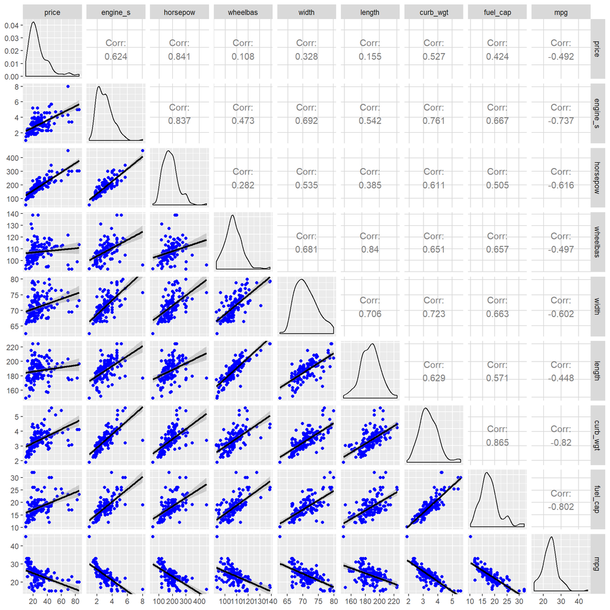

```r
# The Scatterplot Matrix
cars %>%
  select_if(is.numeric) %>%
  ggpairs(lower = list(continuous = wrap("smooth_lm", color = 'blue')))
```

All numerical variables are correlate with `mpg`. But one can also see, that many of them are also correlated with each other. For example, a correlation coefficient for a car’s `length` and `wheelbase` is .84. This indicates, that when included in the model, both variables will bear a very similar information about a car:

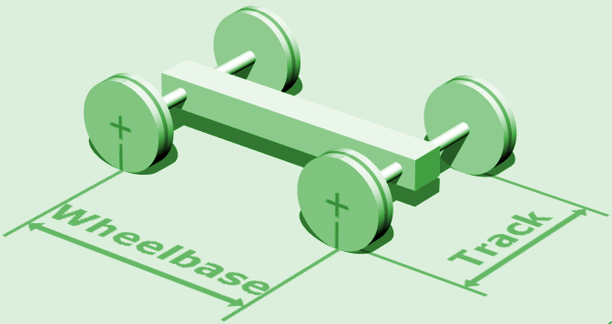

Wheelbase

The term **Multicollinearity** denotes a situation when several predictors in a model are highly correlated. They bear duplicated information about observations. Multicollinearity is a strong linear relationship between two or more predictors in a model.

## The impact of multicollinearity

Let’s consider, how multicollinearity impacts the model. We’ll compare a model containing just `curb_wgt` (weight), `horsepow` (engine’s power) as a predictor and a model which also contains the `fuel_cap` (fuel tank capacity) variable. On its own the latter variable is a good predictor for `mpg` and has a second-largest correlation coefficient with `mpg`: $r = -0.80$. It is however also correlated with the `curb_wgt`: $r = 0.86$.

We’ll compare the models side by side using `memisc::mtable()` function.

```r
m_wgtpow <- lm(mpg ~ curb_wgt + horsepow, data = cars)
m_wgtpowfuel <- lm(mpg ~ curb_wgt + horsepow + fuel_cap, data = cars)

mtable(m_wgtpow, m_wgtpowfuel)
```

```
##
## Calls:
## m_wgtpow: lm(formula = mpg ~ curb_wgt + horsepow, data = cars)
## m_wgtpowfuel: lm(formula = mpg ~ curb_wgt + horsepow + fuel_cap, data = cars)
##
## =========================================
##                 m_wgtpow   m_wgtpowfuel
## -----------------------------------------
##   (Intercept)   42.567***    42.525***
##                 (1.054)      (0.991)
##   curb_wgt      -4.782***    -2.463***
##                 (0.387)      (0.627)
##   horsepow      -0.014**     -0.015***
##                 (0.004)      (0.004)
##   fuel_cap                   -0.423***
##                              (0.093)
## -----------------------------------------
##   R-squared      0.693        0.731
##   N            152          152
## =========================================
##   Significance: *** = p < 0.001;
##                 ** = p < 0.01;
##                 * = p < 0.05
```

In deeper manuals on multiple regression you can learn, that the coefficient estimates are correlated to each other. This relationship is described by the *variance-covariance matrix*, which is another by-product of the Least Squares procedure. This matrix contains variances for coefficient estimates (i.e. squared standard errors of the coefficients) on the main diagonal. The non-diagonal elements are covariances for pairs of coefficients.

```r
round(vcov(m_wgtpowfuel), 3)
```

```
##             (Intercept) curb_wgt horsepow fuel_cap
## (Intercept)       0.982   -0.285    0.000    0.001
## curb_wgt         -0.285    0.393   -0.001   -0.047
## horsepow          0.000   -0.001    0.000    0.000
## fuel_cap          0.001   -0.047    0.000    0.009
```

If two coefficient have a large covariance then the standard error for these will increase. When one of such predictors is dropped from the model, the estimated slope coefficient for the other will change. In some cases, this may even lead to an opposite sign of the remaining coefficient (i.e. the estimated relationship will change its direction). For example, in a demand forecasting model the price can get a positive slope, which is very strange from a practical point of view.

## How to measure multicollinearity?

To quantify multicollinearity, the **variance inflation factor** is computed for each of the predictors in the model:

$$VIF_j = \frac{1}{1-R^2_j}, j=1 \ldots k$$

Here $R^2_j$ is a determination coefficient for a regression model where the predictor $x_j$ is the outcome, and the remaining $ k - 1 $ predictors are explanatory variables. This shows us, how close the information contained in $ x_j $ can be reproduced using the remaining predictors. For a model with $k = 2$ predictors, $R^2_j$ - is just the squared correlation coefficient for these two predictors.

When predictor $x_j$ is not linearly related to other predictors (i.e. it bears completely new information) then $R^2_j = 0$ and $VIF_j = 1$. When there’s such relationship, $VIF_j > 1$.

Whem $VIF_j \approx 1$, the multicollinearity is small or absent. This predictor doesn’t inflate the standard errors for other model’s coefficients.

When $VIF_j \gg 1$, the estimate for its slope is unstable. It may change significantly when other predictors are added to the model, or it may become insignificant. Large $ VIF $ means duplicate information added with different predictors. The information added with a predictor having large $ VIF $ was already explained by other predictors.

When $VIF > 4$ we can assume a strong multicollinearity.

To compute $VIF$ in r, `car::vif()` function is used:

```r
vif(m_wgtpowfuel) %>%
  round(1)
```

```
## curb_wgt horsepow fuel_cap
##      4.7      1.6      4.0
```

Despite the fact multicollinearity complicates the inference (increased SE’s and correlated coefficient estimates), it doesn’t impair prediction in any way. The only problem here would be the case, when the number of observations is small, and number of included predictors is large. This will produce an overly flexible model which can overfit the training data.

## Linear dependency among predictors

There is one case, when extreme multicollinearity leads to inability to estimate the model’s coefficients. This happens when some included predictors are perfectly linearly related. The Ordinary Least Squares involves inversion of the data matrix, which can’t be performed when linearly dependent columns are present.

Let’s demonstrate this on an example. We’ll try to estimate a model, that predicts car’s `mpg` based on it’s width both in inches and centimeters. Clearly, two width measures are proportionally, i.e. linearly dependent to each other.

```r
cars_multi <- cars %>%
  mutate(width_cm = width * 2.54)

m_width_cm <- lm(mpg ~ width_cm, data = cars_multi)
coef(m_width_cm) # no problem
```

```
## (Intercept)    width_cm
##      77.050      -0.295
```

```r
m_width_both <- lm(mpg ~ width + width_cm, data = cars_multi)
coef(m_width_both) # only one slope can be estimated, the other is excluded
```

```
## (Intercept)       width    width_cm
##      77.050      -0.748          NA
```

## Linearly related dummy variables

A particular case for linear dependence is a so called **dummy trap**, when the dummy variables, included into a model are linearly dependent.

This happens, when we include a dummy variable for each level of a categorical variable. For exaxmple, when we include a dummy for each level of vehicle `type` - automobile and truck - the resulting two dummy variables will be perfectly linearly dependent, since we know, that exactly one of them should be 1:

$$automobile + truck = 1$$

Thus, when both variables are included in the model, one slope coefficient can’t be estimated:

```r
cars_dummy <- cars %>%
  mutate(truck = ifelse(type == 'Truck', 1, 0),
         automobile = ifelse(type == 'Automobile', 1, 0))

m_dummy <- lm(mpg ~ horsepow + truck + automobile, data = cars_dummy)
coef(m_dummy) # Only one slope for a dummy variable is estimated
```

```
## (Intercept)    horsepow       truck  automobile
##      33.788      -0.046      -5.521          NA
```

This is why the number of dummy variables should be one less the number of categories.

In R, the categorical variables should be preferably treated as factors. This simplifies modeling and prevents the dummy trap. Text variables will be automatically converted to factors. However you may wish to control the factor levels manually, to select a suitable baseline category, which will correspond to the first factor level. By default, the ordering of levels will be alphabetical.

```r
lm(mpg ~ horsepow + type, data = cars) %>%
  coef() # Only dummy for type = Truck is included
```

```
## (Intercept)    horsepow   typeTruck
##      33.788      -0.046      -5.521
```

# Feature selection

## The Full Model

Let’s estimate a **full model** that includes all available predictors.

```r
m_full <- lm(mpg ~ ., data = select(cars, country:mpg)) # . means 'all remaining variables'

summary(m_full)
```

```
##
## Call:
## lm(formula = mpg ~ ., data = select(cars, country:mpg))
##
## Residuals:
##    Min     1Q Median     3Q    Max
## -6.654 -1.029  0.003  1.008 11.636
##
## Coefficients:
##              Estimate Std. Error t value Pr(>|t|)
## (Intercept)  39.11049    5.04830    7.75  1.7e-12 ***
## countryJapan  1.39782    0.60128    2.32   0.0215 *
## countryUSA    2.02917    0.68949    2.94   0.0038 **
## typeTruck    -3.20122    0.68318   -4.69  6.5e-06 ***
## price         0.04769    0.02832    1.68   0.0945 .
## engine_s     -1.10242    0.44745   -2.46   0.0150 *
## horsepow     -0.01911    0.00868   -2.20   0.0293 *
## wheelbas      0.06803    0.04873    1.40   0.1648
## width        -0.06902    0.08822   -0.78   0.4353
## length       -0.02091    0.03060   -0.68   0.4955
## curb_wgt     -1.41505    0.71937   -1.97   0.0512 .
## fuel_cap     -0.22041    0.09586   -2.30   0.0230 *
## ---
## Signif. codes:  0 '***' 0.001 '**' 0.01 '*' 0.05 '.' 0.1 ' ' 1
##
## Residual standard error: 2.02 on 140 degrees of freedom
## Multiple R-squared:  0.796,  Adjusted R-squared:  0.779
## F-statistic: 49.5 on 11 and 140 DF,  p-value: <2e-16
```

```r
vif(m_full) %>% round(1)
```

```
##          GVIF Df GVIF^(1/(2*Df))
## country   3.3  2             1.3
## type      3.4  1             1.8
## price     6.2  1             2.5
## engine_s  8.2  1             2.9
## horsepow  9.0  1             3.0
## wheelbas  5.2  1             2.3
## width     3.5  1             1.9
## length    6.3  1             2.5
## curb_wgt  7.7  1             2.8
## fuel_cap  5.3  1             2.3
```

Some predictors have large VIFs. Some slopes are not significant due to large standard errors.

The cause for this can be seen in the scatterplot matrix at the top of this tutorial: we’ve learned, that many car’s attributes are correlated and bear the same information. To improve the interpretability of the model, we can simplify it by removing some predictors.

## Criteria for selecting the best model

The most popular metric for comparing regression models is $R^2$. Hovewer, it has an issue of always preferring a larger model. Because of this, it can be used only for comparing models with the same number of predictors.

To overcome this issue, other metrics are used for model selection:

All of these metrics use the same principle: they penalize the model for having larger number of predictors. I.e. the residual standard error, or the proportion of unexplained variance are increased proportionally to the number of predictors.

We’ll demonstrate this on example of Adjusted $ R^2 $, AIC and BIC:

**Adjusted $R^2$** is defined as:

$$R^2_{adj} = 1 - (1-R^2) \cdot \frac{n-1}{n-k-1}$$

For larger number of predictors $k$ the fraction at the right hand side is larger. So, the product of of it and the *un*explained variance proportion $(1-R^2)$ is also larger. This ultimately leads to lower explained variance proportion.

**Akaike Information Criterion (AIC)** is calculated based on residual sum of squares $RSS$ and includes a penalty which is dependent on the number of predictors $k$:

$$AIC = n \ln (RSS/n) + 2(k+2)$$

AIC has no upper/lower limits in contrast to $R^2_{adj}$. Lower values are better.

When the number of observations $n$ is small, using the above formula tends to prefer models with too many predictors. For such cases, a **corrected AIC** (AICc) has been introduced. In this metric, the penalty for complexity is gradually decreasing when the sample size $n$ is increasing:

$$AICc = AIC + \frac{2 (k+2) (k+3)}{n - k - 3}$$

** Bayesian Information Criterion (BIC)** is similar to AIC, but the penalty term is different:

$$BIC = n \ln (RSS/n) + (k+2) \cdot \ln n$$

BIC has a larger penalty compared to AIC, so using it tends to select models with smaller number of predictors

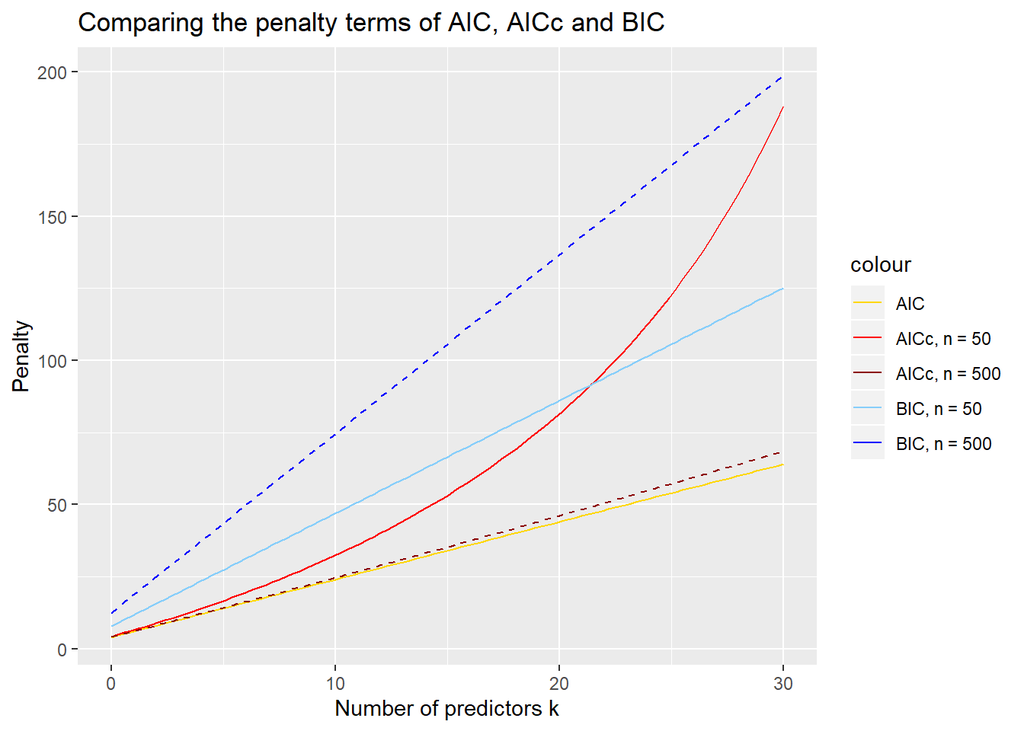

## Best subsets regression

For smaller datasets the best model according to selected criterion can be choosen using the complete enumeration of all possible models. For 3 predictors, we could consider one model without predictors, 3 one-predictor models, 3 two-predictor models and one 3-predictor model - 8 in total. For a given number of predictors $k$ the number of models to consider is growing exponentially and is $2^k$. For $k = 20$ predictors the number of models to compare is about 1 million.

In R, we use the `leaps::regsubsets()` function, that does best subsets regression. The maximum number of predictors in the model $ k_{max} k $ can be provided as a parameter. The function returns the list of best models for each number of predictors from 1 to $ k_{max} $. By default, the function selects the best model based on $R^2_{adj}$ metric.

```r
best_models <- leaps::regsubsets(mpg ~ ., # all predictors are considered
                                 nbest = 2,  # two best models for each number of predictors
                                 nvmax = 10, # maximum number of predictors, 8 by default
                                 data = select(cars, country:mpg))

# Summary of the models selected
summary(best_models)
```

```
## Subset selection object
## Call: regsubsets.formula(mpg ~ ., nbest = 2, nvmax = 10, data = select(cars,
##     country:mpg))
## 11 Variables  (and intercept)
##              Forced in Forced out
## countryJapan     FALSE      FALSE
## countryUSA       FALSE      FALSE
## typeTruck        FALSE      FALSE
## price            FALSE      FALSE
## engine_s         FALSE      FALSE
## horsepow         FALSE      FALSE
## wheelbas         FALSE      FALSE
## width            FALSE      FALSE
## length           FALSE      FALSE
## curb_wgt         FALSE      FALSE
```

[output cut: 45 more lines]

The results can be visualized, though only base R graphics can be used for this.

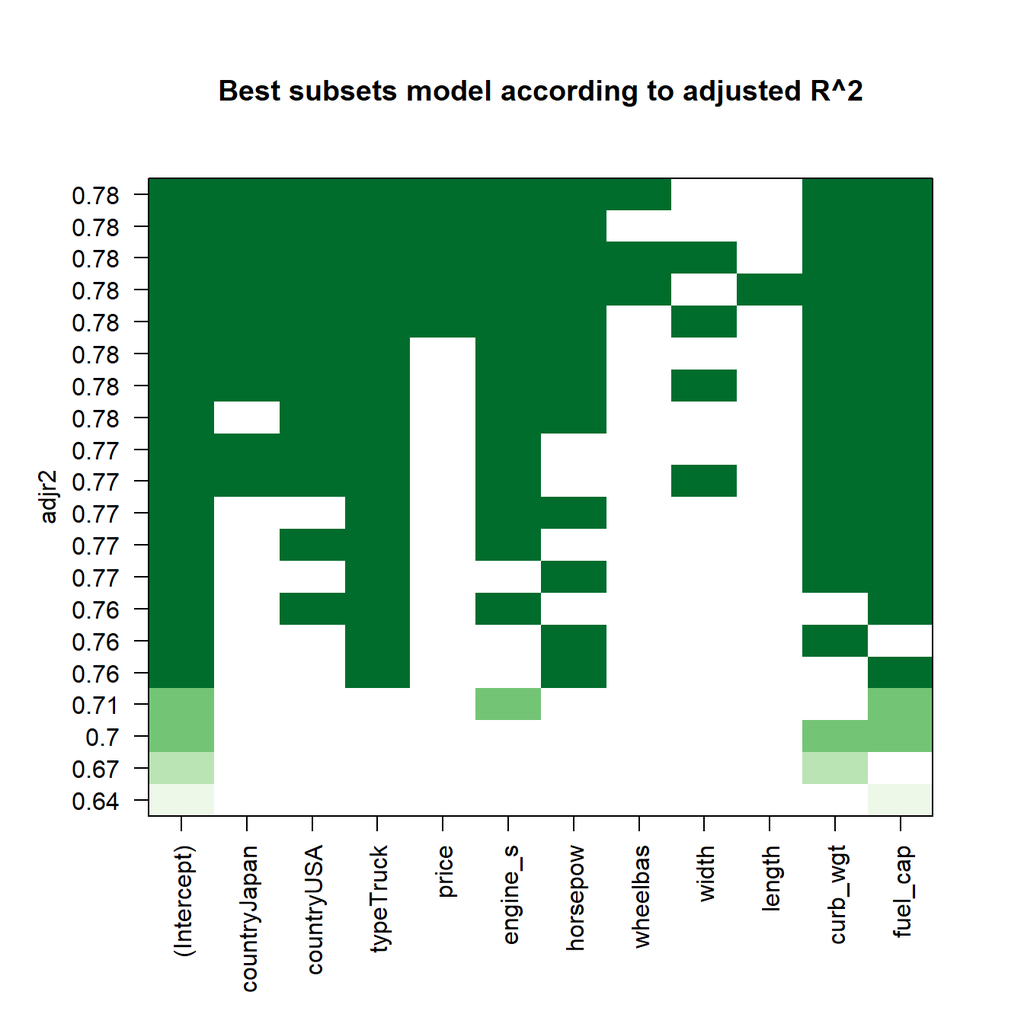

```r
# By default, the plot will use black fill color. Let's chose something less depressing
# See RColorBrewer::display.brewer.all()
mycolors <- rev(RColorBrewer::brewer.pal(n = 5, name = 'Greens'))

# Plotting the model summary
plot(best_models, scale = "adjr2", col = mycolors,
     main = "Best subsets model according to adjusted R^2")
```

Each row on a plot is a model. The models are ordered by $R^2_{adj}$. The filled cells denote selected predictors, the blank cells represent predictors not included into a model.

The best model is on top. For our example, this model includes all the variables except the width and length.

Alternative model ranking can be specified, which will produce a different list of best moderls. If we choose BIC, which has largel penalty for complexity, smaller models will be preferred:

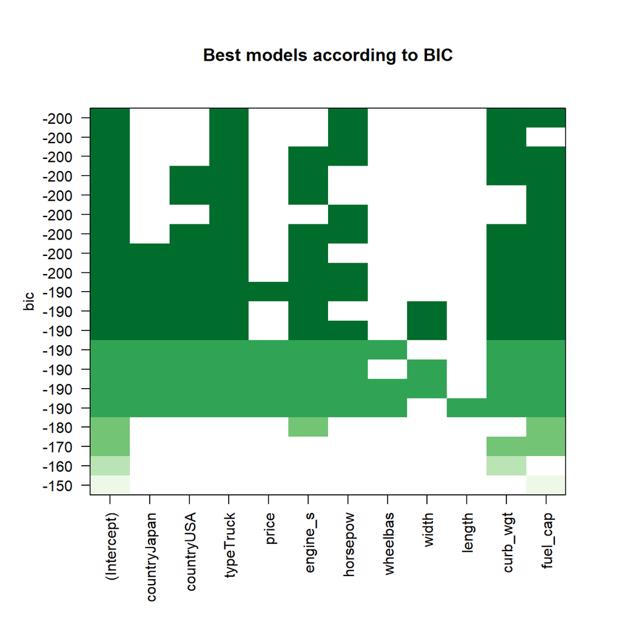

```r
# Plotting the summary
plot(best_models, scale = "bic", col = mycolors,
     main = "Best models according to BIC")
```

**Limitations of the method**

Despite best subsets regression can select the best possible model for a given number of predictors, it’s use is subject to the following limitations:

- It’s computationally demanding for large number of predictors. The numbers of models to consider is $ 2^k $ for $k$ predictors
- Different selection criteria lead to different best models. It’s up to the modeler, which metric to select. If model sparsity is preferred, BIC is the best option.
- The method can’t automatically deal with non-linear relationships and interactions. The modeler must explore data for the presence of such relationships and include the corresponding terms to the model’s specification.

## Stepwise regression

**Stepwise regression** is a heuristic algorithm for variable selection. It is used when a number of predictors is large and best subsets regression is infeasible. The stepwise algorithm works iteratively. At each step, a selection of the best variable to include or exclude is made. There are 3 variations of the algorithm:

- **Backward stepwise** - an approach, where a large model is iteratively simplified by removing the weakest predictors;
- **Forward stepwise** - an approach, where variables are iteratively added to a simple model, until its quality is improving;
- **Stepwise stepwise** - an approach, where at each step a variable can be added, while another variable can be also removed from the model.

To quantify the model quality, a penalized criterion is used - AIC, BIC or adjusted $R^2$ for example.

In R, these algorithms are implemented in the `MASS:stepAIC()` function.

Let’s consider some examples of stepwise regression.

### Backward stepwise in R

The method tries to simplify the initial complex model. The function takes as an input a regular regression model created with `lm()`.

```r
m_backward <- stepAIC(m_full, direction = "backward")
```

```
## Start:  AIC=226
## mpg ~ country + type + price + engine_s + horsepow + wheelbas +
##     width + length + curb_wgt + fuel_cap
##
##            Df Sum of Sq RSS AIC
## - length    1       1.9 574 224
## - width     1       2.5 575 224
## <none>                  572 226
## - wheelbas  1       8.0 580 226
## - price     1      11.6 584 226
## - curb_wgt  1      15.8 588 228
## - horsepow  1      19.8 592 229
## - fuel_cap  1      21.6 594 229
## - engine_s  1      24.8 597 230
## - country   2      35.6 608 231
## - type      1      89.7 662 246
##
## Step:  AIC=224
## mpg ~ country + type + price + engine_s + horsepow + wheelbas +
##     width + curb_wgt + fuel_cap
##
##            Df Sum of Sq RSS AIC
## - width     1       2.6 577 223
## - wheelbas  1       6.8 581 224
## <none>                  574 224
## - price     1      13.7 588 226
## - horsepow  1      21.8 596 228
## - curb_wgt  1      21.9 596 228
## - fuel_cap  1      23.1 597 228
## - engine_s  1      24.1 598 228
## - country   2      34.0 608 229
## - type      1     108.3 682 248
##
## Step:  AIC=223
## mpg ~ country + type + price + engine_s + horsepow + wheelbas +
##     curb_wgt + fuel_cap
##
##            Df Sum of Sq RSS AIC
## - wheelbas  1       5.1 582 222
## <none>                  577 223
## - price     1      15.4 592 225
## - country   2      31.6 608 227
## - horsepow  1      24.4 601 227
## - engine_s  1      24.8 602 227
## - fuel_cap  1      25.9 603 227
## - curb_wgt  1      28.7 605 228
## - type      1     106.5 683 246
##
## Step:  AIC=222
## mpg ~ country + type + price + engine_s + horsepow + curb_wgt +
##     fuel_cap
##
##            Df Sum of Sq RSS AIC
## <none>                  582 222
## - price     1      12.2 594 223
## - fuel_cap  1      21.4 603 226
## - horsepow  1      22.1 604 226
## - curb_wgt  1      23.8 606 226
## - engine_s  1      28.2 610 227
## - country   2      37.3 619 228
## - type      1     114.4 696 247
```

You can suppress the output of intermediate models at each step using `trace = F` argument. You can also change the weight of the penalty term (`k`). By default, it’s 2 (this corresponds to AIC). You can change it to log(n), where `n` is the number of observations. This will correspond to BIC.

### Forward stepwise in R

For using forward stepwise or stepwise stepwise algorithms, the range of models to consider should be provided. To do so, provide the initial simplest and the most complex model to consider using the `scope =` argument. In the following example we’ll use the null and the full model:

```r
# The null model
m_null <- lm(mpg ~ 1, data = dplyr::select(cars, country:mpg))

# Forward Stepwise
m_forward <- stepAIC(m_null,
                     scope = list(lower = m_null, upper = m_full),
                     direction = 'forward')
```

```
## Start:  AIC=445
## mpg ~ 1
##
##            Df Sum of Sq  RSS AIC
## + curb_wgt  1      1880  918 277
## + fuel_cap  1      1799  999 290
## + engine_s  1      1521 1277 328
## + horsepow  1      1062 1736 374
## + width     1      1015 1783 378
## + type      1       931 1867 385
## + wheelbas  1       692 2106 404
## + price     1       676 2122 405
## + length    1       561 2238 413
## <none>                  2798 445
## + country   2         2 2797 449
##
## Step:  AIC=277
## mpg ~ curb_wgt
##
##            Df Sum of Sq RSS AIC
## + fuel_cap  1      95.9 822 263
## + engine_s  1      85.7 832 264
## + type      1      81.7 836 265
## + horsepow  1      59.7 858 269
## + length    1      21.6 896 276
## + price     1      13.7 904 277
## <none>                  918 277
## + wheelbas  1       6.5 912 278
## + width     1       0.5 917 279
## + country   2       5.4 913 280
##
## Step:  AIC=263
## mpg ~ curb_wgt + fuel_cap
##
##            Df Sum of Sq RSS AIC
## + engine_s  1      80.9 741 249
## + horsepow  1      68.8 753 251
## + type      1      37.1 785 258
## + length    1      28.4 794 259
## + wheelbas  1      26.1 796 260
```

[output cut: 45 more lines]

```
## + price     1     12.19 582 222
## <none>                  594 223
## + width     1      2.42 592 225
## + wheelbas  1      1.95 592 225
## + length    1      0.13 594 225
##
## Step:  AIC=222
## mpg ~ curb_wgt + fuel_cap + engine_s + type + country + horsepow +
##     price
##
##            Df Sum of Sq RSS AIC
## <none>                  582 222
## + wheelbas  1      5.14 577 223
## + width     1      0.87 581 224
## + length    1      0.45 581 224
```

### Stepwise stepwise

```r
m_stepwise <- stepAIC(m_null,
                      scope = list(lower = m_null, upper = m_full),
                      direction = 'both')
```

```
## Start:  AIC=445
## mpg ~ 1
##
##            Df Sum of Sq  RSS AIC
## + curb_wgt  1      1880  918 277
## + fuel_cap  1      1799  999 290
## + engine_s  1      1521 1277 328
## + horsepow  1      1062 1736 374
## + width     1      1015 1783 378
## + type      1       931 1867 385
## + wheelbas  1       692 2106 404
## + price     1       676 2122 405
## + length    1       561 2238 413
## <none>                  2798 445
## + country   2         2 2797 449
##
## Step:  AIC=277
## mpg ~ curb_wgt
##
##            Df Sum of Sq  RSS AIC
## + fuel_cap  1        96  822 263
## + engine_s  1        86  832 264
## + type      1        82  836 265
## + horsepow  1        60  858 269
## + length    1        22  896 276
## + price     1        14  904 277
## <none>                   918 277
## + wheelbas  1         6  912 278
## + width     1         1  917 279
## + country   2         5  913 280
## - curb_wgt  1      1880 2798 445
##
## Step:  AIC=263
## mpg ~ curb_wgt + fuel_cap
##
##            Df Sum of Sq RSS AIC
## + engine_s  1      80.9 741 249
## + horsepow  1      68.8 753 251
## + type      1      37.1 785 258
## + length    1      28.4 794 259
```

[output cut: 73 more lines]

```
## mpg ~ curb_wgt + fuel_cap + engine_s + type + country + horsepow +
##     price
##
##            Df Sum of Sq RSS AIC
## <none>                  582 222
## + wheelbas  1       5.1 577 223
## - price     1      12.2 594 223
## + width     1       0.9 581 224
## + length    1       0.5 581 224
## - fuel_cap  1      21.4 603 226
## - horsepow  1      22.1 604 226
## - curb_wgt  1      23.8 606 226
## - engine_s  1      28.2 610 227
## - country   2      37.3 619 228
## - type      1     114.4 696 247
```

For comparison, we’ll use BIC for model selection using the stepwise stepwise algorithm

```r
m_stepwise_BIC <- stepAIC(m_null,
                      scope = list(lower = m_null, upper = m_full),
                      direction = 'both',
                      trace = FALSE,
                      k = log(nrow(cars))) # BIC uses a penalty of (k + 2) * log(n)

m_stepwise_BIC
```

```
##
## Call:
## lm(formula = mpg ~ curb_wgt + fuel_cap + type + horsepow, data = dplyr::select(cars,
##     country:mpg))
##
## Coefficients:
## (Intercept)     curb_wgt     fuel_cap    typeTruck     horsepow
##     39.7385      -1.7529      -0.2503      -2.8987      -0.0255
```

Now we’ll compare the best models obtained with different selection algorithms:

```r
# The best model from best subsets regression using BIC
m_best <- lm(mpg ~ type + horsepow + curb_wgt + fuel_cap, data = cars)

memisc::mtable(m_backward, m_forward, m_stepwise, m_stepwise_BIC, m_best)
```

```
##
## Calls:
## m_backward: lm(formula = mpg ~ country + type + price + engine_s + horsepow +
##     curb_wgt + fuel_cap, data = select(cars, country:mpg))
## m_forward: lm(formula = mpg ~ curb_wgt + fuel_cap + engine_s + type + country +
##     horsepow + price, data = dplyr::select(cars, country:mpg))
## m_stepwise: lm(formula = mpg ~ curb_wgt + fuel_cap + engine_s + type + country +
##     horsepow + price, data = dplyr::select(cars, country:mpg))
## m_stepwise_BIC: lm(formula = mpg ~ curb_wgt + fuel_cap + type + horsepow, data = dplyr::select(cars,
##     country:mpg))
## m_best: lm(formula = mpg ~ type + horsepow + curb_wgt + fuel_cap, data = cars)
##
## ==========================================================================================
##                           m_backward  m_forward   m_stepwise  m_stepwise_BIC    m_best
## ------------------------------------------------------------------------------------------
##   (Intercept)              37.921***   37.921***   37.921***     39.738***     39.738***
##                            (1.286)     (1.286)     (1.286)       (1.044)       (1.044)
##   country: Japan/Europe     1.261*      1.261*      1.261*
##                            (0.572)     (0.572)     (0.572)
##   country: USA/Europe       1.903**     1.903**     1.903**
##                            (0.629)     (0.629)     (0.629)
##   type: Truck/Automobile   -2.917***   -2.917***   -2.917***     -2.899***     -2.899***
##                            (0.550)     (0.550)     (0.550)       (0.536)       (0.536)
##   price                     0.047       0.047       0.047
##                            (0.027)     (0.027)     (0.027)
##   engine_s                 -1.163**    -1.163**    -1.163**
##                            (0.442)     (0.442)     (0.442)
##   horsepow                 -0.020*     -0.020*     -0.020*       -0.026***     -0.026***
##                            (0.008)     (0.008)     (0.008)       (0.004)       (0.004)
##   curb_wgt                 -1.482*     -1.482*     -1.482*       -1.753**      -1.753**
##                            (0.612)     (0.612)     (0.612)       (0.589)       (0.589)
##   fuel_cap                 -0.207*     -0.207*     -0.207*       -0.250**      -0.250**
##                            (0.090)     (0.090)     (0.090)       (0.091)       (0.091)
## ------------------------------------------------------------------------------------------
##   R-squared                 0.792       0.792       0.792         0.775         0.775
##   N                       152         152         152           152           152
## ==========================================================================================
##   Significance: *** = p < 0.001; ** = p < 0.01; * = p < 0.05
```

**Limitations of the method**

In our example, all three stepwise regression algorithms produced the same result (using AIC). When the selected metric was changed to BIC, a simpler model was produced. This model appeared to be the same, as proposed by the best subsets regression (also using BIC). In general, this may not be the case, since all stepwise algorithms are **greedy**. A **greedy algorithm** makes the locally optimal decision at each step (selecting a variable with largest improvement in the metric in case of stepwise regression). But this approach doesn’t guarantee convergence to the best possible model.

Also, as with the best subsets regression, the analyst is responsible for modeling non-linear relationships and interactions. The variable selection methods are unable to consider them automatically.

## Regularization

As we’ve seen, multicollinearity of predictors complicates the inference by inflating the standard errors for coefficient estimates. This is not an issue for a pure prediction task. But larger models are also more flexible, and flexibility may lead to overfitting training data, when the ratio of sample size to the number of coefficients is low (there are different estimates: some sources say it should be greater than 4, others - greater than 10). In case when the number of coefficients is equal or less to the sample size, the coefficients can’t be estimated at all.

A model that is tuned too much to training data captures not only the true relationship between predictors and the outcome, but also the noise in data. A simpler, less flexible model, would be more stable on new data.

We’ve considered a few methods to make a multiple regression less flexible by constraining the number of predictors in the model. There is another approach to decrease the model complexity. Instead of limiting the number of predictors, we could constrain the magnitude of the coefficients $\hat\beta_j$ themselves. Such approach is called **regularization**. To constrain the coefficients, it uses a penalty term dependent on the magnitude of coefficients, which is added to the loss function.

There are 2 variants of regularizations based on different penalty terms.

- The **ridge regression** uses sum of squared slope coefficients as a penalty term (L2-norm):

$$RSS(\hat\beta) + \lambda \sum_{j=1} ^k {\hat\beta_j^2} \to min$$

Note that only the slope coefficients are included in the penalty term. The intercept $\hat\beta_0$ is not included.

- The **Lasso regression** (*Least absolute shrinkage and selection operator*) uses the sum of coefficient magnitudes (L1-norm):

$$RSS(\hat\beta) + \lambda \sum_{j=1} ^k |\hat\beta_j| \to min$$

An useful property of the Lasso method is its ability to completely exclude some predictos by shrinking their slope coefficients to zero.

Both penalty terms contain $\lambda$ - a hyperparameter that determines the weight of the penalty. This hyperparameter can be tuned empirically, by comparing the model performance on test data.

In R both methods are implemented in the `glmnet` package. This package also contains a hybrid method **elastic net**, that combines the penalty terms from both Ridge and Lasso regression:

$$RSS(\hat\beta) + \lambda \left(\alpha\sum_{j=1} ^k |\hat\beta_j| + (1 - \alpha) \sum_{j=1} ^k {\hat\beta_j^2} \right) \to min$$

Here $\alpha$ is another hyperparameter, that blends the penalty terms from both methods.

### Data pre-processing for glmnet

Unfortunately, the `glmnet` package can’t use data frames or tibbles, so the input data must be pre-processed. The predictors should be placed into a matrix. If there are categorical variables, they must be dummy-coded. The oucome variable should be a separate vector.

```r
y <- cars$mpg

X <- cars %>%
  mutate(truck = ifelse(type == 'Truck', 1, 0),
         europe = ifelse(country == 'Europe', 1, 0)) %>%
  select(-(manufact:type), -mpg) %>%
  as.matrix()

head(X, 4)
```

```
##      price engine_s horsepow wheelbas width length curb_wgt fuel_cap truck europe
## [1,]  21.5      1.8      140      101  67.3    172     2.64     13.2     0      0
## [2,]  28.4      3.2      225      108  70.3    193     3.52     17.2     0      0
## [3,]  42.0      3.5      210      115  71.4    197     3.85     18.0     0      0
## [4,]  24.0      1.8      150      103  68.2    178     3.00     16.4     0      1
```

### Ridge regression using glmnet

Now we’ll estimate a Ridge regression model using `glmnet`. For this, we set $\alpha = 0$, and $\lambda$ will be automatically selected.

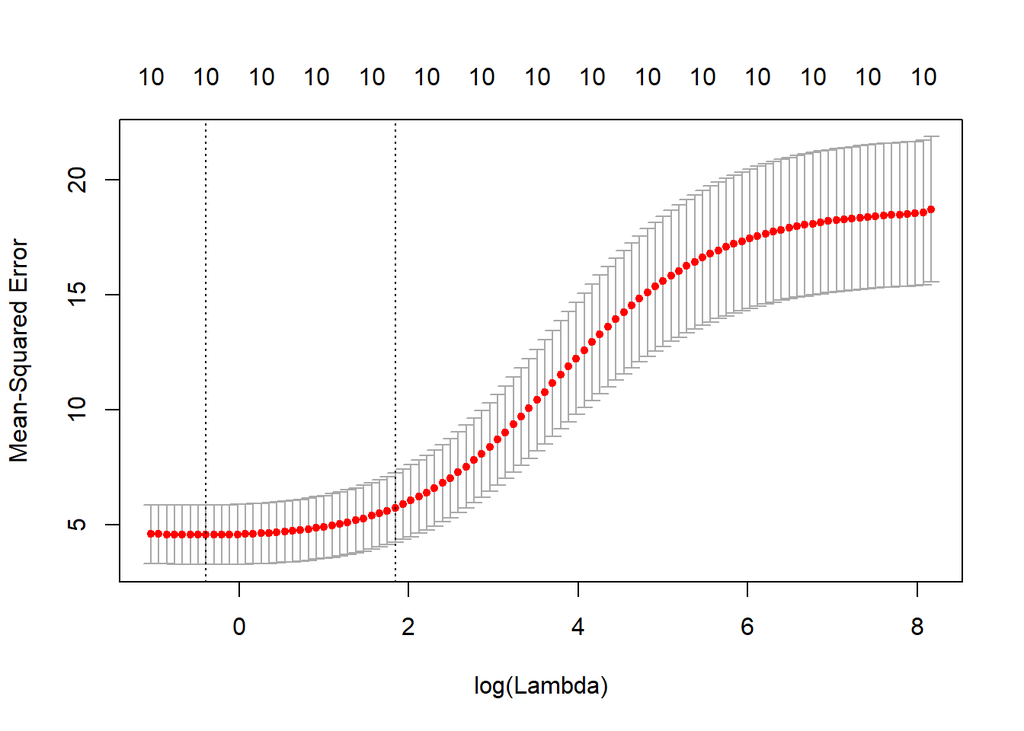

```r
# Tuning lambda hyperparameter
set.seed(12345)
cv_ridge <- cv.glmnet(X, y, alpha = 0, parallel = T)


# Plotting the model test set error depending on lambda
plot(cv_ridge, xvar = "lambda")
```

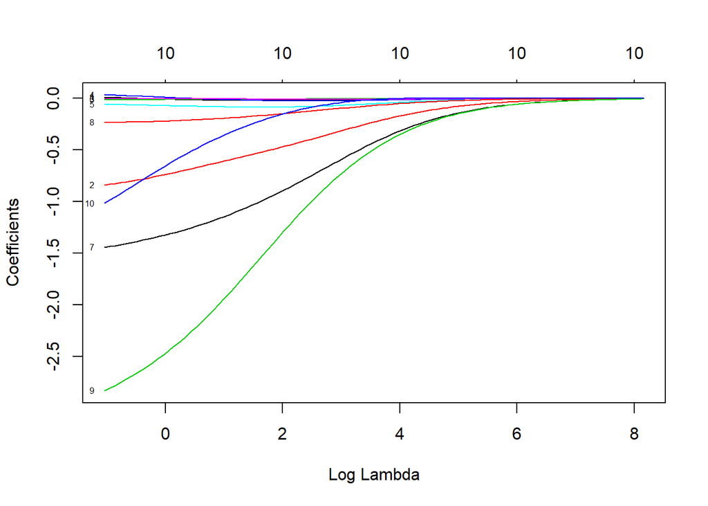

```r
# Plotting the model coefficients depending on lambda
plot(cv_ridge$glmnet.fit, xvar = "lambda", label = T)
```

Larger $\lambda$ shrinks the coefficients towards zero.

By default, `glmnet()` standardizes the coefficients, to make the penalty term scale independent. If necessary, we can disable standardization by adding `standardize = FALSE` argument.

```r
# Best lambda
cat("The minimal error is obtained with lambda =", cv_ridge$lambda.min, "\n\n")
```

```
## The minimal error is obtained with lambda = 0.675
```

```r
# Best model coefficients (according to test set error)
coef(cv_ridge, s = c(0, cv_ridge$lambda.min))
```

```
## 11 x 2 sparse Matrix of class "dgCMatrix"
##                   1        2
## (Intercept) 40.1526 41.15767
## price        0.0106 -0.00163
## engine_s    -0.8386 -0.78193
## horsepow    -0.0144 -0.01229
## wheelbas     0.0350  0.01942
## width       -0.0566 -0.06514
## length      -0.0058 -0.00263
## curb_wgt    -1.4435 -1.37365
## fuel_cap    -0.2333 -0.22710
## truck       -2.8317 -2.62438
## europe      -1.0162 -0.78906
```

The column labeled `1` contains the coefficient for the model without regularization ($\lambda = 0$), and the `2` column contains the coefficients for a model with the optimal $\lambda$.

Let’s predict `mpg` for a car with the following attributes:

- price: 40 K$,
- engine size: 4 литра,
- horsepower: 300,
- wheelbase: 130 inches,
- width: 70 inches,
- length: 200 inches,
- weight: 4 k pounds,
- fuel tank capacity: 20 gallons.

The predictors should be placed into a matrix. In our case the matrix will contain just one row for a single car.

You can see other methods to create a matrix in help: `?matrix`.

```r
new_car <- tibble( # a table with one row
   price = 40,
   engine_s = 4,
   horsepow = 300,
   wheelbas = 130,
   width = 70,
   length = 200,
   curb_wgt = 4,
   fuel_cap = 20,
   truck = 0,
   europe = 1) %>%
  as.matrix() # converting to a matrix

new_car
```

```
##      price engine_s horsepow wheelbas width length curb_wgt fuel_cap truck europe
## [1,]    40        4      300      130    70    200        4       20     0      1
```

```r
# Forecast
pred <- predict(cv_ridge, newx = new_car, s = c(0, cv_ridge$lambda.min))

# Printing the output
colnames(pred) <- c("Without Regularization", "With Regularization")
pred
```

```
##      Without Regularization With Regularization
## [1,]                   20.9                20.9
```

In this example, the results are identical, since the coefficients haven’t changed much by regularization.

### Lasso regression using glmnet

Now we build a Lasso regression model. We set $\alpha = 1$, and $\lambda$ will be auto-selected.

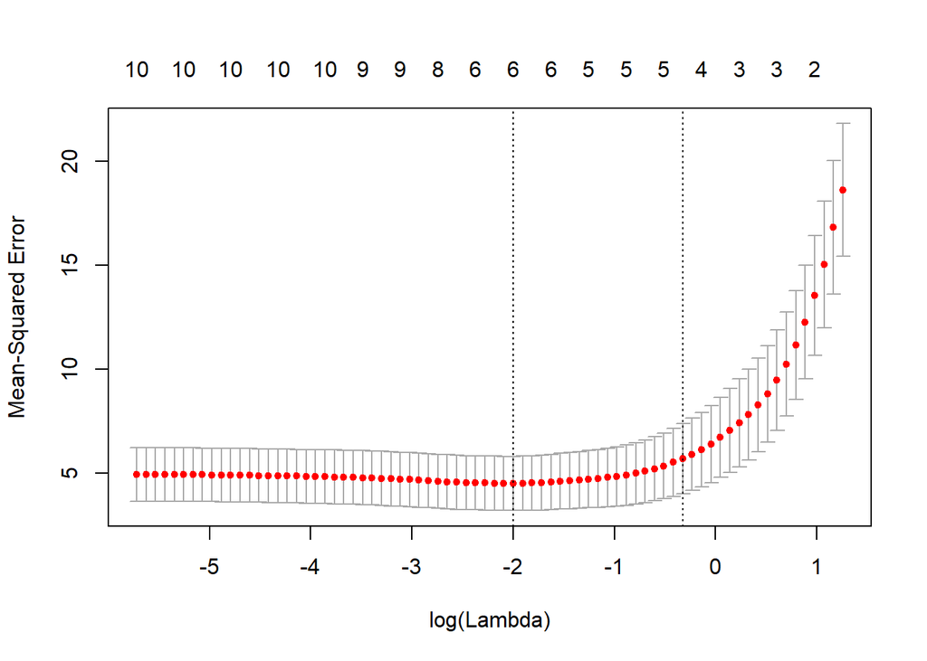

```r
# Tuning the lambda
set.seed(12345)
cv_lasso <- cv.glmnet(X, y, alpha = 1, parallel = T)


# Plotting the model test set error depending on lambda
plot(cv_lasso, xvar = "lambda")
```

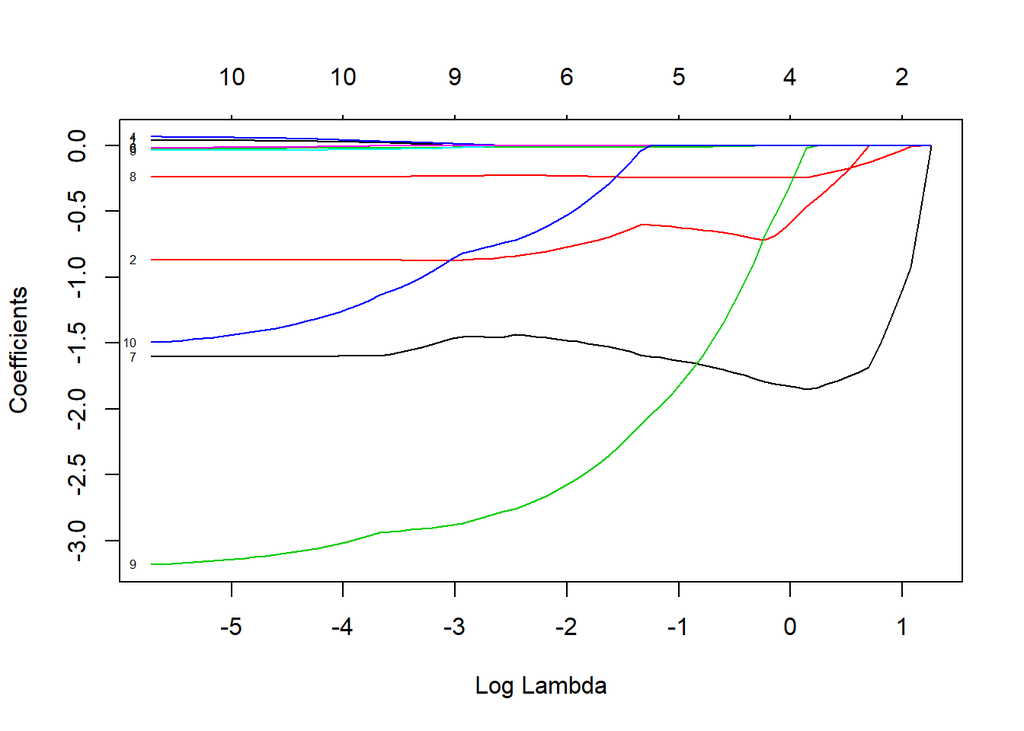

```r
# Plotting the model coefficients depending on lambda
plot(cv_lasso$glmnet.fit, xvar = "lambda", label = T)
```

Notice how the coefficients are shrinking towards zero with increased $\lambda$. In contrast to Ridge regression, at some points some coefficients become exactly zero, and the corresponding predictor is effectively removed from the model.

```r
# Best lambda
cat("The minimal error is obtained with lambda =", cv_lasso$lambda.min, "\n\n")
```

```
## The minimal error is obtained with lambda = 0.136
```

```r
# Best model coefficients
coef(cv_lasso, s = c(0, cv_lasso$lambda.min))
```

```
## 11 x 2 sparse Matrix of class "dgCMatrix"
##                   1       2
## (Intercept) 38.3934 38.5834
## price        0.0420  .
## engine_s    -0.8668 -0.7719
## horsepow    -0.0211 -0.0134
## wheelbas     0.0672  .
## width       -0.0366  .
## length      -0.0157  .
## curb_wgt    -1.6046 -1.4780
## fuel_cap    -0.2368 -0.2304
## truck       -3.1829 -2.5756
## europe      -1.4952 -0.5243
```

The column labeled `1` contains the coefficient for the model without regularization ($\lambda = 0$), and the `2` column contains the coefficients for a model with the optimal $\lambda$.

Some predictors (`price`, `wheelbas`, `width`, `length`) got the zero slope coefficients and thus were efficiently removed from the model.

Now we’ll make a forecast for the same car using the Lasso model:

```r
# Forecasting
pred <- predict(cv_lasso, newx = new_car, s = c(0, cv_lasso$lambda.min))

# Printing out the forecast
colnames(pred) <- c("Without regularization", "With regularization")

pred
```

```
##      Without regularization With regularization
## [1,]                   20.7                20.4
```

In this case, the results are slightly different, since some variables were removed from the model.

You can see more examples of using `glmnet` package here:

- **Trevor Hastie, Junyang Qian** [glmnet Vignette](https://cran.r-project.org/web/packages/glmnet/vignettes/glmnet_beta.pdf)
- **Ricardo Carvalho** [How to use Ridge Regression and Lasso in R](http://ricardoscr.github.io/how-to-use-ridge-and-lasso-in-r.html)
- Справка по `glmnet`
- ISLR book, 6.6 Lab 2: Ridge Regression and the Lasso on p.251

# Standardization and centering of predictors

## What predictors are influencing the outcome the most?

Let’s consider the best model according to BIC.

```r
tidy(m_stepwise_BIC)
```

```
## # A tibble: 5 x 5
##   term        estimate std.error statistic  p.value
##   <chr>          <dbl>     <dbl>     <dbl>    <dbl>
## 1 (Intercept)  39.7      1.04        38.1  5.27e-78
## 2 curb_wgt     -1.75     0.589       -2.97 3.44e- 3
## 3 fuel_cap     -0.250    0.0910      -2.75 6.71e- 3
## 4 typeTruck    -2.90     0.536       -5.41 2.55e- 7
## 5 horsepow     -0.0255   0.00422     -6.05 1.13e- 8
```

The model has 4 predictors. By looking just at the coefficients, it’s not possible to tell, what is the most important predictor. The slope coefficients are scale-dependent. So, the weight is measured in thousand pounds, the data values are below 10. The horsepower has a magnitude of a few hundred. The coefficients reflect the units selected for predictors, and can’t be compared directly.

```r
cars_dummy %>%
  select(curb_wgt, fuel_cap, truck, horsepow) %>%
  map(range) %>%
  as_tibble()
```

```
## # A tibble: 2 x 4
##   curb_wgt fuel_cap truck horsepow
##      <dbl>    <dbl> <dbl>    <dbl>
## 1     1.90     10.3     0       55
## 2     5.57     32       1      450
```

To compare the coefficients, we can scale all predictors. One way of such scaling is standardization, when all predictors are replaced with z-scores:

$$z = \frac{x - \bar{x}}{S_x}$$

All values are replaced with their deviation from the average, measured in the number of standard deviations. For example, $z=-1.5$ means that the corresponding value for $x$ was 1.5 standard deviations below the average.

This method works the best, when the distribution of predictors is close to a normal. In shuch case, all scaled predictors will have the same standard normal distribution. The asymmetry in data distribution can prevent this.

R includes a function for standardization - `scale()`.

You can scale only quantitative variables. The categorical variables must be first dummy coded.

```r
cars_dummy_z <- cars_dummy  %>%
  mutate_if(is.numeric, scale)

cars_dummy_z_tall <- cars_dummy_z %>%
  select(curb_wgt, fuel_cap, truck, horsepow, mpg) %>%
  gather(key = "Variable", value = "Value", curb_wgt:mpg)

# Descriptive statistics
cars_dummy_z_tall %>%
  group_by(`Variable`) %>%
  summarize(`Average` = round(mean(`Value`), 3),
            `Standard Deviation` = sd(`Value`))
```

```
## # A tibble: 5 x 3
##   Variable Average `Standard Deviation`
##   <chr>      <dbl>                <dbl>
## 1 curb_wgt       0                1.000
## 2 fuel_cap       0                1.000
## 3 horsepow       0                1
## 4 mpg            0                1.
## 5 truck          0                1.000
```

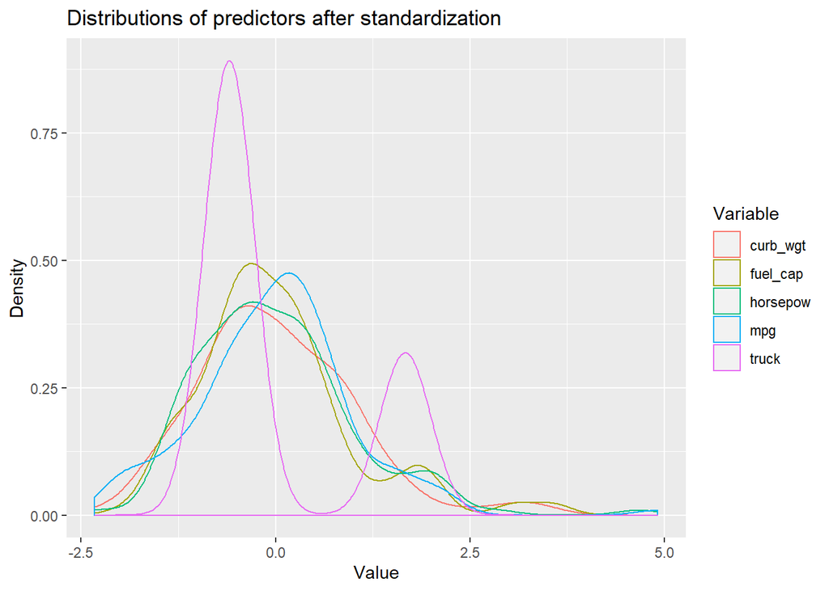

```r
# Plotting distributions
ggplot(data = cars_dummy_z_tall) +
  geom_density(aes(x = `Value`, colour = `Variable`)) +
  labs(title = "Distributions of predictors after standardization",
       y = "Density")
```

Let’s build a model using standardized predictors and outcome:

```r
m_stepwise_BIC_z <- lm(mpg ~ curb_wgt + fuel_cap + truck + horsepow, data = cars_dummy_z)

tidy(m_stepwise_BIC_z) %>%
  mutate_if(is.numeric, round, digits = 4)
```

```
## # A tibble: 5 x 5
##   term        estimate std.error statistic p.value
##   <chr>          <dbl>     <dbl>     <dbl>   <dbl>
## 1 (Intercept)    0        0.039       0     1
## 2 curb_wgt      -0.259    0.0872     -2.97  0.0034
## 3 fuel_cap      -0.229    0.0833     -2.75  0.0067
## 4 truck         -0.298    0.055      -5.41  0
## 5 horsepow      -0.337    0.0557     -6.05  0
```

Coefficients for a model that uses standardized predictors and outcome are called **standardized coefficients**. The standardized coefficients help to determine, what predictors are the most influential.

In our example increasing horsepower by one standard deviation will decrease `mpg` by 0.337 standard deviations. At the same time, increasing weight by 1 s.d. will decrease the `mpg` by .259 s.d.

As can be seen in the density plot for standardized predictors shown above, using z-scores is not appropriate for dummy variables, since the distribution of such variables is not a normal distribution. Thus, it might be better to exclude the dummy variables from standardization. To make the scale of other predictors comparable to the scale of dummies, we can divide them by two standard deviations instead of one when scaling. In this case, the dummy variables are left intact, and thus the convenient factor functionality can be used.

see Andrew Gelman, [Standardizing regression inputs by dividing by two standard deviations](http://andrewgelman.com/2006/06/21/standardizing_r/)

```r
scale2 <- function(x) {
  scale(x)/2
}

cars_2z <- cars  %>%
  mutate_if(is.numeric, scale2)
```

Coefficients for the model built on data standardized by two s.d.:

```r
m_stepwise_BIC_2z <- lm(mpg ~ curb_wgt + fuel_cap + type + horsepow, data = cars_2z)

tidy(m_stepwise_BIC_2z) %>%
  mutate_if(is.numeric, round, digits = 4)
```

```
## # A tibble: 5 x 5
##   term        estimate std.error statistic p.value
##   <chr>          <dbl>     <dbl>     <dbl>   <dbl>
## 1 (Intercept)   0.0886    0.0255      3.48  0.0007
## 2 curb_wgt     -0.259     0.0872     -2.97  0.0034
## 3 fuel_cap     -0.229     0.0833     -2.75  0.0067
## 4 typeTruck    -0.337     0.0623     -5.41  0
## 5 horsepow     -0.337     0.0557     -6.05  0
```

The result is similar to the previous one. The most important predictor is `horsepow`. Vehicle type is the second most important predictor.

## A zero weight car?

Let’s consider again the model for non-standardized data

```r
tidy(m_stepwise_BIC) %>% select(term:estimate)
```

```
## # A tibble: 5 x 2
##   term        estimate
##   <chr>          <dbl>
## 1 (Intercept)  39.7
## 2 curb_wgt     -1.75
## 3 fuel_cap     -0.250
## 4 typeTruck    -2.90
## 5 horsepow     -0.0255
```

The slope coefficients have a straightforward interpretation: increasing weight by 1 thousand pounds decreased the mpg on 1.75 miles, on average. But how about the intercept? The model tells us, that a zero-weight, zero-horsepower, zero-fuel capacity automobile would have `mpg` of 39.7 miles. Such a result is mathematically correct, but hard to interpret in practice.

To simplifty the interpretation of the intercept in cases when zero values for predictors are not possible in practice, we can use another transformation of predictors. **Centering** a predictor replaces its values with deviations from the average for that predictor. It is similar to standardization, but we are not dividing by the s.d.

$$x_c = x - \bar{x}$$

After centering, the average for the predictor becomes zero, and the resulting values show deviations from an average, or ‘typical’ value.

In R, centering is performed by the same `scale()` function with an additional argument `scale = F`.

```r
cars_c <- cars %>%
  mutate_at(c("curb_wgt", "fuel_cap", "horsepow"), # these variables will be centered
            scale, # the function to apply
            scale = F) %>% # disable scaling
  mutate(horsepow = horsepow / 100) # let's also rescale the units for horsepower to 100 hps to make ranges of predictors comparable


cars_c %>% head(3)
```

```
## # A tibble: 3 x 14
##   manufact model manufact_model country type  price engine_s horsepow[,1] wheelbas
##   <chr>    <chr> <chr>          <chr>   <chr> <dbl>    <dbl>        <dbl>    <dbl>
## 1 Acura    Inte~ Acura Integra  Japan   Auto~  21.5      1.8       -0.448     101.
## 2 Acura    TL    Acura TL       Japan   Auto~  28.4      3.2        0.402     108.
## 3 Acura    RL    Acura RL       Japan   Auto~  42        3.5        0.252     115.
## # ... with 5 more variables: width <dbl>, length <dbl>, curb_wgt[,1] <dbl>,
## #   fuel_cap[,1] <dbl>, mpg <dbl>
```

Now we build a model with centered predictors

```r
m_stepwise_BIC_c <- lm(mpg ~ curb_wgt + fuel_cap + type + horsepow, data = cars_c)

mtable(m_stepwise_BIC, m_stepwise_BIC_c)
```

```
##
## Calls:
## m_stepwise_BIC: lm(formula = mpg ~ curb_wgt + fuel_cap + type + horsepow, data = dplyr::select(cars,
##     country:mpg))
## m_stepwise_BIC_c: lm(formula = mpg ~ curb_wgt + fuel_cap + type + horsepow, data = cars_c)
##
## ============================================================
##                           m_stepwise_BIC  m_stepwise_BIC_c
## ------------------------------------------------------------
##   (Intercept)                39.738***        24.604***
##                              (1.044)          (0.219)
##   curb_wgt                   -1.753**         -1.753**
##                              (0.589)          (0.589)
##   fuel_cap                   -0.250**         -0.250**
##                              (0.091)          (0.091)
##   type: Truck/Automobile     -2.899***        -2.899***
##                              (0.536)          (0.536)
##   horsepow                   -0.026***        -2.554***
##                              (0.004)          (0.422)
## ------------------------------------------------------------
##   R-squared                   0.775            0.775
##   N                         152              152
## ============================================================
##   Significance: *** = p < 0.001; ** = p < 0.01;
##                 * = p < 0.05
```

The slope coefficients didn’t change (except for `horsepow` which has been scaled). The interpretation of slope coefficients didn’t change. Still, increasing the horsepower by 1 hundred hp would decrease the `mpg` by 2.55 miles on average (with all other attributes of a car kept equal).

# Residual Diagnostics

For multiple regression, the residual diagnostics is used to check if the assumptions of the model are met, and if the model can be improved by incorporating some remaining relationships between residuals and predictors.

## Residuals from the baseline model

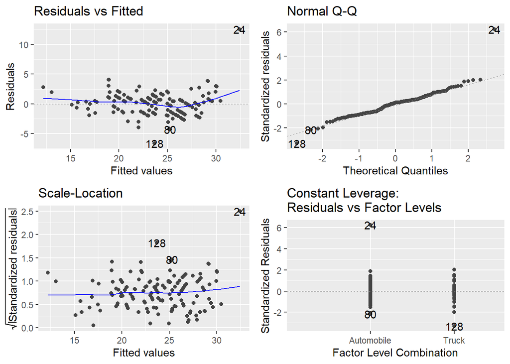

```r
autoplot(m_stepwise_BIC)
```

The Residuals vs Fitted plot reveals a slight curvature, that comes from the non-linearity in the true relationship. Based on this, we can try to incorporate such non-linearity into the model by either transforming the variables, or by including polynomial terms. The deviation from normality is evident only at the tails of the distribution, as shown on the Q-Q plot. The hederoscedasticity is not visible.

## Outliers and influential observations

Let’s explore the outliers and the influential observations in more detail. For this, we construct a plot showing both the residuals, and the two metrics for assessment of the observation’s influence on the model - Cook’s D and Leverage.

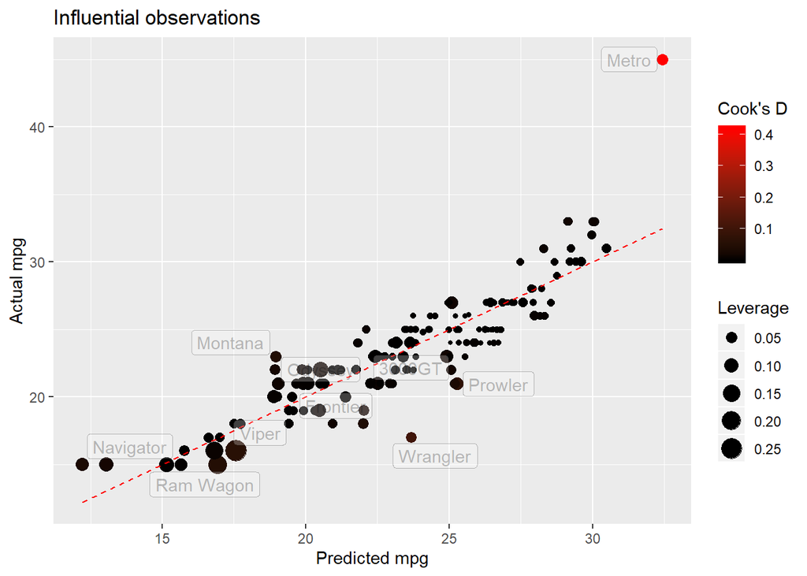

```r
fit_stepwise_BIC <- m_stepwise_BIC %>%
  fortify() %>% # saved residuals, fitted values and influence statistics from the model to the data table
  merge(., cars) # added the original columns


ggplot(fit_stepwise_BIC, aes(.fitted, mpg)) +
  geom_point(aes(size = .hat, colour = .cooksd)) +
  geom_line(aes(.fitted, .fitted),
            colour = "red", linetype = "dashed") +
  scale_colour_gradient(low = "black", high = "red") +
  ggrepel::geom_label_repel(
    data = filter(fit_stepwise_BIC, .cooksd > 4/nrow(cars)),
    mapping = aes(label = model), alpha = 0.25) +
  labs(title = "Influential observations",
       x = "Predicted mpg", y = "Actual mpg",
       size = "Leverage", colour = "Cook's D")
```

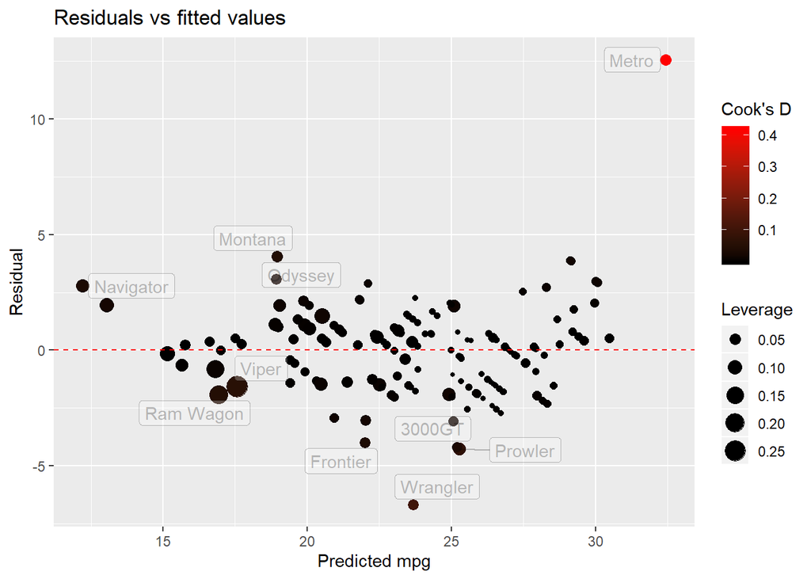

```r
ggplot(fit_stepwise_BIC, aes(.fitted, .resid)) +
  geom_point(aes(size = .hat, colour = .cooksd)) +
  geom_hline(yintercept = 0,
            colour = "red", linetype = "dashed") +
  scale_colour_gradient(low = "black", high = "red") +
  ggrepel::geom_label_repel(
    data = filter(fit_stepwise_BIC, .cooksd > 4/nrow(cars)),
    mapping = aes(label = model), alpha = 0.25) +
  labs(title = "Residuals vs fitted values",
       x = "Predicted mpg", y = "Residual",
       colour = "Cook's D", size = "Leverage")
```

The largest residual corresponds to [Chevrolet Metro](https://wiki.zr.ru/Chevrolet_Metro). This is the smallest and the most economical model among american cars.

## Non-linear transformation of the outcome variable

One way of accounting for the non-linearity of the relationship is using the power transformation of the outcome variable. We can estimate the required parameter of the power transformation using the `car::powerTransform()` function. This function searches for the beset transformation power aiming at making the distribution of the residuals as normal as possible.

```r
powerTransform(m_stepwise_BIC)
```

```
## Estimated transformation parameter
##     Y1
## -0.155
```

The transform parameter is best rounded to make the resulting model more interpretable. The value we’ve obtained is quite close to 0, which corresponds to the log-transformation.

Now we try to estimate a model with the transformed outcome variable.

```r
m_log <- lm(log10(mpg)  ~ curb_wgt + fuel_cap + type + horsepow, data = cars)

tidy(m_log) %>% mutate_if(is.numeric, round, digits = 3)
```

```
## # A tibble: 5 x 5
##   term        estimate std.error statistic p.value
##   <chr>          <dbl>     <dbl>     <dbl>   <dbl>
## 1 (Intercept)    1.66      0.017     96.0    0
## 2 curb_wgt      -0.03      0.01      -3.02   0.003
## 3 fuel_cap      -0.005     0.002     -3.61   0
## 4 typeTruck     -0.058     0.009     -6.50   0
## 5 horsepow       0         0         -6.15   0
```

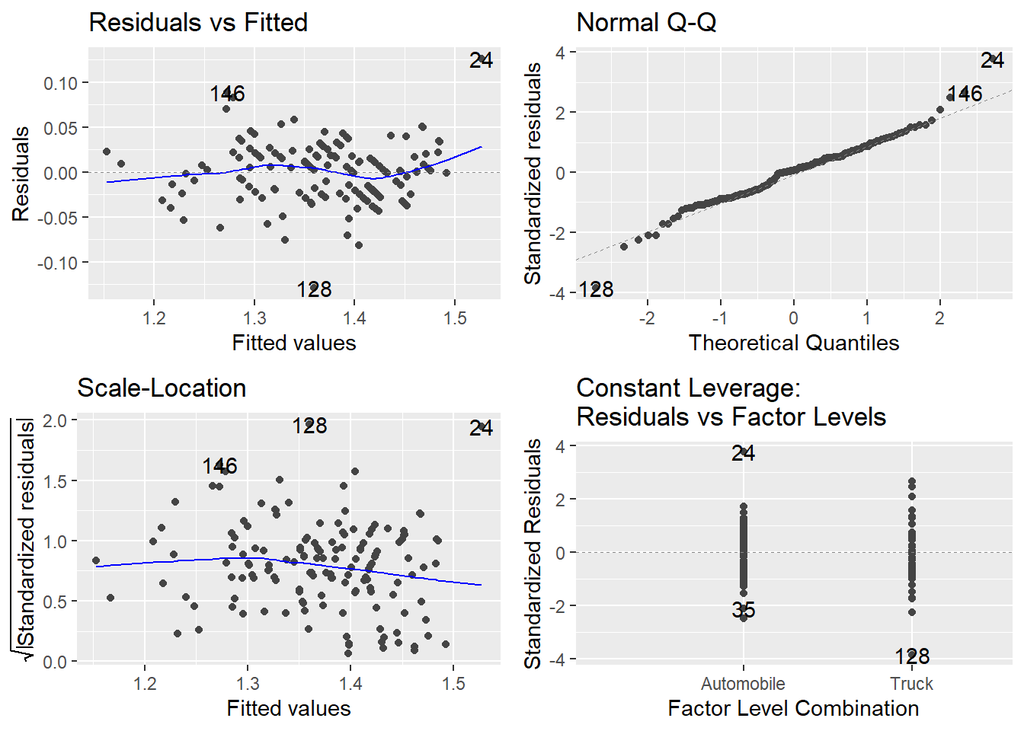

```r
autoplot(m_log)
```

In this case, the transformation didn’t help to remove non-linearity in residuals. Also we can see a side-effect of it on the `Scale-Location` plot: the variance of residuals is now not constant. Based on this, we discard the logarithmic model in favor of the simpler linear one.

## Adding non-linear predictors

When looking for the possible improvements for the model, it’s very useful to look at correlations between residuals and the predictors.

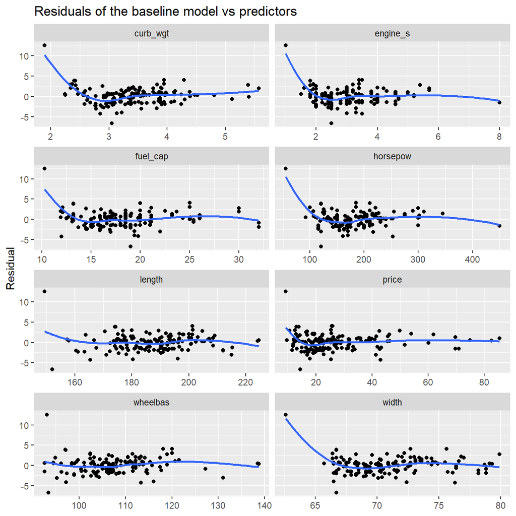

```r
fit_cars_stepwise <- cars %>%
  add_residuals(m_stepwise_BIC) %>%
  gather(key = "Variable", value = "Value", price:fuel_cap)

ggplot(fit_cars_stepwise, aes(x = `Value`, y = `resid`)) +
  geom_point() +
  geom_smooth(se = F) +
  facet_wrap(~ `Variable`, scales = "free_x", ncol = 2) +
  labs(title = "Residuals of the baseline model vs predictors",
       y = "Residual", x = NULL)
```

Our model includes the following predictors:

```r
coef(m_stepwise_BIC)
```

```
## (Intercept)    curb_wgt    fuel_cap   typeTruck    horsepow
##     39.7385     -1.7529     -0.2503     -2.8987     -0.0255
```

In the next example we can play with different powers of `curb_wgt` variable included into the model. The model stopped to improve after adding the 4th power.

```r
m_poly <- lm(mpg  ~ curb_wgt + I(curb_wgt^2) + I(curb_wgt^3) + I(curb_wgt^4) +
            fuel_cap + type + horsepow,
             data = cars)

mtable(m_stepwise_BIC, m_poly)
```

```
##
## Calls:
## m_stepwise_BIC: lm(formula = mpg ~ curb_wgt + fuel_cap + type + horsepow, data = dplyr::select(cars,
##     country:mpg))
## m_poly: lm(formula = mpg ~ curb_wgt + I(curb_wgt^2) + I(curb_wgt^3) +
##     I(curb_wgt^4) + fuel_cap + type + horsepow, data = cars)
##
## =======================================================
##                           m_stepwise_BIC    m_poly
## -------------------------------------------------------
##   (Intercept)                39.738***     300.919***
##                              (1.044)       (37.430)
##   curb_wgt                   -1.753**     -283.866***
##                              (0.589)       (43.796)
##   fuel_cap                   -0.250**       -0.240***
##                              (0.091)        (0.071)
##   type: Truck/Automobile     -2.899***      -3.147***
##                              (0.536)        (0.425)
##   horsepow                   -0.026***      -0.023***
##                              (0.004)        (0.003)
##   I(curb_wgt^2)                            111.083***
##                                            (18.737)
##   I(curb_wgt^3)                            -18.990***
##                                             (3.470)
##   I(curb_wgt^4)                              1.192***
##                                             (0.234)
## -------------------------------------------------------
##   R-squared                   0.775          0.865
##   N                         152            152
## =======================================================
##   Significance: *** = p < 0.001; ** = p < 0.01;
##                 * = p < 0.05
```

The $R^2$ has improved and all the polynomial terms are significant.

Now we have a more complex model:

$$\widehat{mpg} = 301 - 284 curb\_wgt + 111 curb\_wgt^2 - 19.0 curb\_wgt^3 + 1.192 curb\_wgt^4 -\\
- 0.240 fuel\_cap - 3.15 (type = Truck) - 0.023 horsepow$$

Let’s explore the residuals.

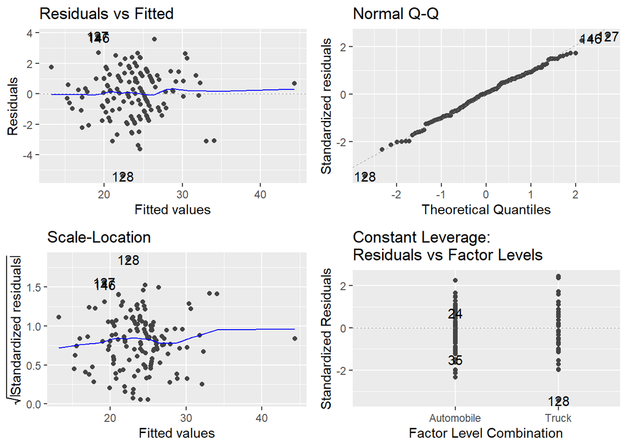

```r
autoplot(m_poly)
```

This looks much better now, the non-linearity is not noticeable.

## Checking for correlations with other predictors

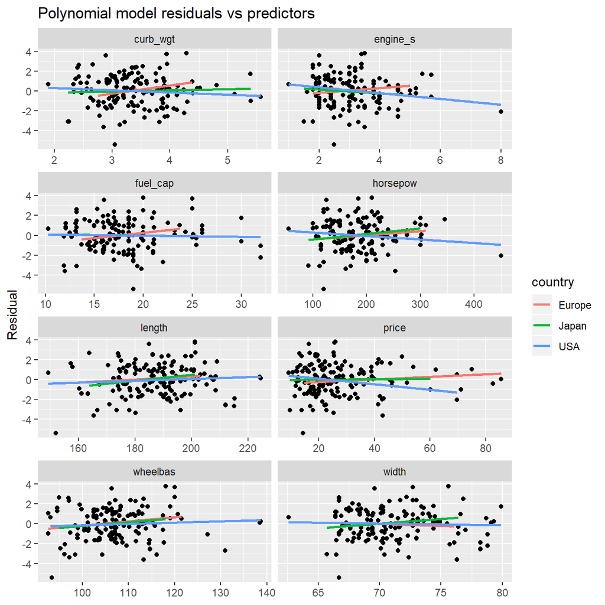

```r
fit_cars_poly <- cars %>%
  add_residuals(m_poly) %>%
  gather(key = "Variable", value = "Value", price:fuel_cap)

ggplot(fit_cars_poly, aes(x = `Value`, y = `resid`)) +
  geom_point() +
  geom_smooth(aes(color = country), se = F, method = 'lm') +
  facet_wrap(~ `Variable`, scales = "free_x", ncol = 2) +
  labs(title = "Polynomial model residuals vs predictors",
       y = "Residual", x = NULL)
```

There are no visible correlations with the quantitative predictors. We’ve added also split by country of origin, which might suggest to try adding the country variable and its interaction with `horsepow` and `price`.

```r
m_poly_country <- lm(mpg  ~ curb_wgt + I(curb_wgt^2) + I(curb_wgt^3) + I(curb_wgt^4) +
            fuel_cap + type + horsepow * country + price * country,
             data = cars)

mtable(m_stepwise_BIC, m_poly, m_poly_country)
```

```
##
## Calls:
## m_stepwise_BIC: lm(formula = mpg ~ curb_wgt + fuel_cap + type + horsepow, data = dplyr::select(cars,
##     country:mpg))
## m_poly: lm(formula = mpg ~ curb_wgt + I(curb_wgt^2) + I(curb_wgt^3) +
##     I(curb_wgt^4) + fuel_cap + type + horsepow, data = cars)
## m_poly_country: lm(formula = mpg ~ curb_wgt + I(curb_wgt^2) + I(curb_wgt^3) +
##     I(curb_wgt^4) + fuel_cap + type + horsepow * country + price *
##     country, data = cars)
##
## ========================================================================
##                            m_stepwise_BIC    m_poly     m_poly_country
## ------------------------------------------------------------------------
##   (Intercept)                 39.738***     300.919***    301.578***
##                               (1.044)       (37.430)      (39.160)
##   curb_wgt                    -1.753**     -283.866***   -284.882***
##                               (0.589)       (43.796)      (45.493)
##   fuel_cap                    -0.250**       -0.240***     -0.283***
##                               (0.091)        (0.071)       (0.073)
##   type: Truck/Automobile      -2.899***      -3.147***     -3.082***
##                               (0.536)        (0.425)       (0.449)
##   horsepow                    -0.026***      -0.023***     -0.021
##                               (0.004)        (0.003)       (0.016)
##   I(curb_wgt^2)                             111.083***    111.655***
##                                             (18.737)      (19.441)
##   I(curb_wgt^3)                             -18.990***    -19.138***
##                                              (3.470)       (3.597)
##   I(curb_wgt^4)                               1.192***      1.207***
##                                              (0.234)       (0.243)
##   country: Japan/Europe                                    -1.418
##                                                            (1.954)
##   country: USA/Europe                                       0.963
##                                                            (1.701)
##   price                                                     0.010
##                                                            (0.049)
##   horsepow x countryJapan                                   0.023
##                                                            (0.020)
##   horsepow x countryUSA                                     0.007
##                                                            (0.018)
##   countryJapan x price                                     -0.101
##                                                            (0.067)
##   countryUSA x price                                       -0.089
##                                                            (0.070)
## ------------------------------------------------------------------------
##   R-squared                    0.775          0.865         0.874
##   N                          152            152           152
## ========================================================================
##   Significance: *** = p < 0.001; ** = p < 0.01; * = p < 0.05
```

None of the additional predictors are significant, so we’ll keep the previous polynomial model

Finally, let’s compare the predicted and the actual values.

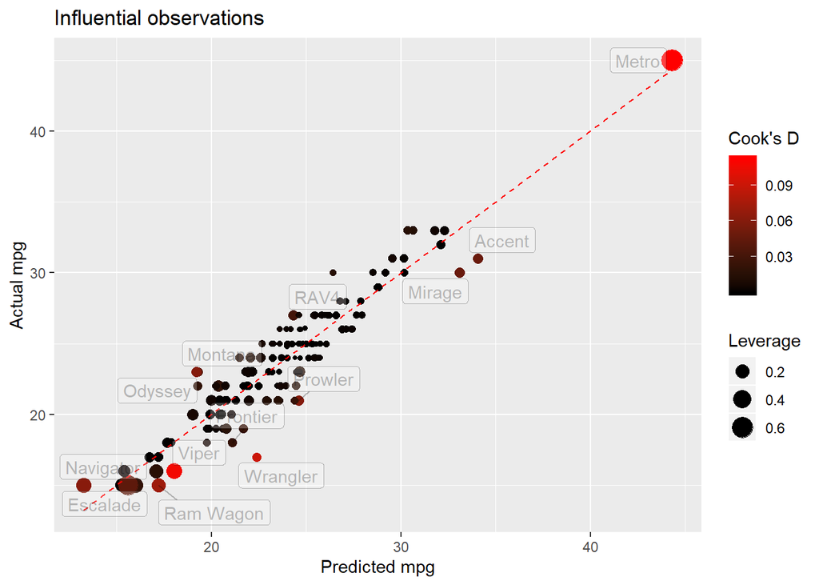

```r
fit_cars_poly <- m_poly %>%
  fortify() %>% # saved the residuals, fitted values and influence statistics to a data frame
  merge(., cars) # added original data

ggplot(fit_cars_poly, aes(.fitted, mpg)) +
  geom_point(aes(colour = .cooksd, size = .hat)) +
  geom_line(aes(.fitted, .fitted),
            colour = "red", linetype = "dashed") +
  scale_colour_gradient(low = "black", high = "red") +
  ggrepel::geom_label_repel(
    data = filter(fit_cars_poly, .cooksd > 4/nrow(cars)),
    mapping = aes(label = model), alpha = 0.25) +
  labs(title = "Influential observations",
       x = "Predicted mpg", y = "Actual mpg",
       colour = "Cook's D", size = "Leverage")
```

Compared to the residuals from the previous model (see Outliers and influential observations), the curvature of the point cloud is not noticeable. The points are symmetrically distributed across the ‘Perfect fit’ line, the residuals are much smaller.

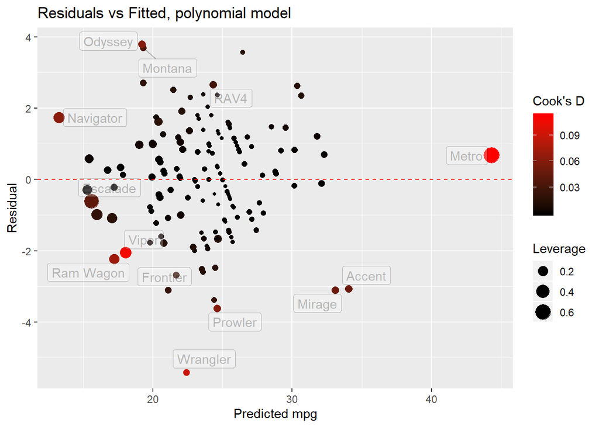

```r
ggplot(fit_cars_poly, aes(.fitted, .resid)) +
  geom_point(aes(size = .hat, colour = .cooksd)) +
  geom_hline(yintercept = 0,
            colour = "red", linetype = "dashed") +
  scale_colour_gradient(low = "black", high = "red") +
  ggrepel::geom_label_repel(
    data = filter(fit_cars_poly, .cooksd > 4/nrow(cars)),
    mapping = aes(label = model), alpha = 0.25) +
  labs(title = "Residuals vs Fitted, polynomial model",
       x = "Predicted mpg", y = "Residual",
       colour = "Cook's D", size = "Leverage")
```

The largest Cook’s D corresponds to economy cars(Chevrolet Metro, Hyundai Accent, Mitsubishi Mirage), large automobiles (Dodge Ram Wagon, Cadillac Escalade, Lincoln Navigator, Honda Odyssey, Toyota RAV4, Jeep Wrangler) and sport cars (Dodge Viper, Plymouth Prowler). We don’t have a variable for a car class in our data, but it might be a good predictor for mpg, which could improve the model.